# Nutritional status of women in Gabon

AYONG MORE

2025-07-13

# 1 Introduction

The nutritional status of women is a key determinant of public health and development, particularly in low- and middle-income countries. In Sub-Saharan Africa, women face multiple challenges that contribute to undernutrition and overnutrition, including poverty, low education levels, limited access to healthcare, and socio-cultural practices.

In Gabon, the 2012 Demographic and Health Survey (DHS) revealed a dual burden of malnutrition: while a portion of women remain undernourished, an increasing number face overweight and obesity, particularly in urban areas. This nutritional imbalance is associated with socioeconomic disparities, including differences in education, household wealth, and place of residence. Malnutrition among women not only affects their own health and well-being but also has inter-generational effects, influencing child growth, pregnancy outcomes, and the long-term development of communities.

Given this context, it is essential to understand the underlying factors contributing to womens nutritional status in Gabon. This study aims to provide a detailed analysis of the risk factors for malnutrition among women of reproductive age, using data from the 2012 DHS.

# 2 Objectives

## 2.1 General objective:

To evaluate the nutritional status of women in Gabon and identify the key factors contributing to malnutrition.

## 2.2 Specific objectives:

- To assess the distribution of women’s nutritional status, including underweight, normal weight, and overweight categories.
- To examine socio-demographic and economic determinants associated with malnutrition among women.
- To derive public health recommendations based on the analysis of the findings.

# 3 Methodology

**Data Source:** Demographic and Health Survey (DHS) – Gabon, 2012 (Dataset: GAIR61FL.DTA)

**Study Population:** Women aged 15 to 49 years residing in Gabon.

**Variables:**

**Dependent Variables:**

- Body Mass Index (BMI) – v445 (divided by 100)
- BMI status (categorized: underweight, normal, overweight/obese)

**Independent Variables:**

- Age in 5 year_groups - 013,
- Region - v024,
- Type of place of residence - v025,
- Height educational level - v106,
- Wealth_index - v190,
- Body mass index - v444a,
- Number of children 5 and under in household (de_jure) - v137)

# 4 Results

## 4.1 Women’s nutritional status (underweight, normal, overweight)

This section aims to describe the distribution of the nutritional status of women aged 15 to 49 in Gabon, based on body mass index (BMI). Analyses include tables presenting the frequencies and proportions of different BMI categories (underweight, normal weight, overweight), as well as a breakdown by age group. Graphical representations (histograms and proportional bar plots) show the distribution of nutritional status in the female population as a whole and by age group.

**Distribution of BMI in categories (underweight, normal, overweight)**

In general, the following WHO BMI ranges (in kg/m2) classify different types of weight, as following:

| BMI_Category | BMI_Range |
| --- | --- |
| Underweight | < 18.5 |
| Optimum range | 18.5 – 24.9 |
| Overweight | 25 – 29.9 |
| Class I Obesity | 30 – 34.9 |
| Class II Obesity | 35 – 39.9 |
| Class III Obesity | ≥ 40 |

[figure not shown]

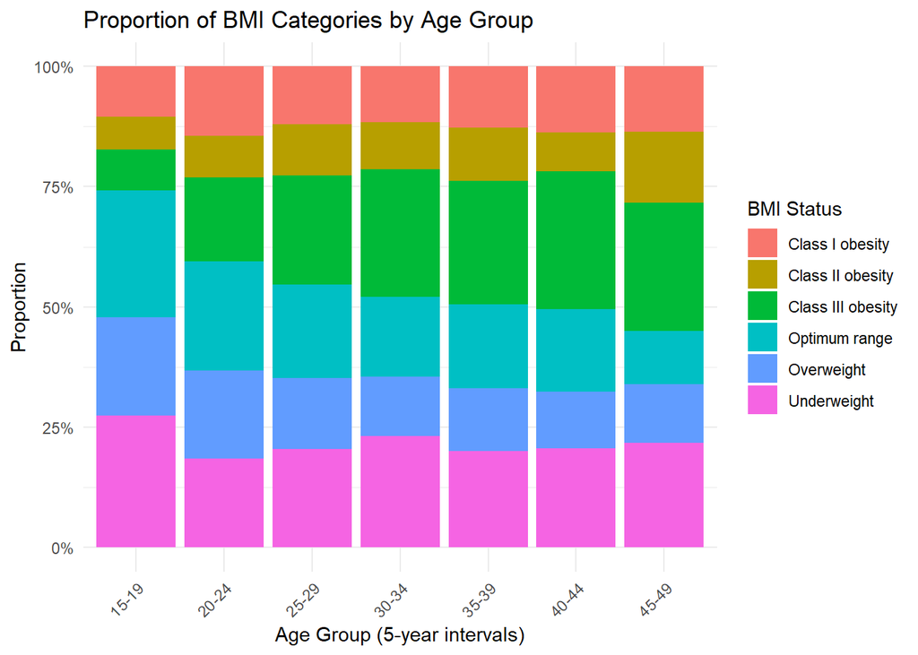

The proportional bar graph illustrates the relative composition of weight status categories (BMI) within each age group. Each bar represents an age group, and the colored segments indicate the proportion of women in each BMI category.

This distribution reflects the double burden of malnutrition: the coexistence of undernutrition in young women and obesity in older women, which calls for targeted interventions according to age group.

## 4.2 Identification of Sociodemographic and Economic Factors Associated with Malnutrition

This section aims to explore and identify key socio-demographic and economic determinants linked to malnutrition among women. We investigate how factors like age, educational level, place of residence (urban/rural), and household wealth index influence nutritional status.

Understanding these associations helps highlight vulnerable populations and underlying causes contributing to undernutrition and overweight/obesity. This insight is critical for designing targeted public health interventions and policies to effectively address malnutrition in diverse demographic groups.

**BMI by women’s level education**

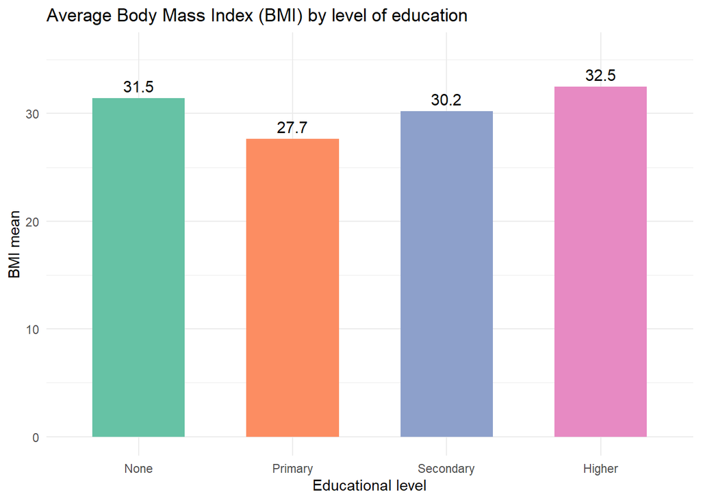

**Women with no education and those with higher education have the highest average BMIs**.

**This shows a U-shaped phenomenon** :

- BMIs are lower among women with primary or secondary education.
- They are higher among women with no education and those with higher education.

**Education and lifestyle**:

- Women with higher levels of education may have:
  - Access to caloric foods, often rich in fats and sugars.
  - A more sedentary lifestyle (office jobs, motorized travel).
- Uneducated women may live in contexts where corpulence is culturally valued or testifies to social status, even in a context of food precariousness

**BMI by women’s wealth index**

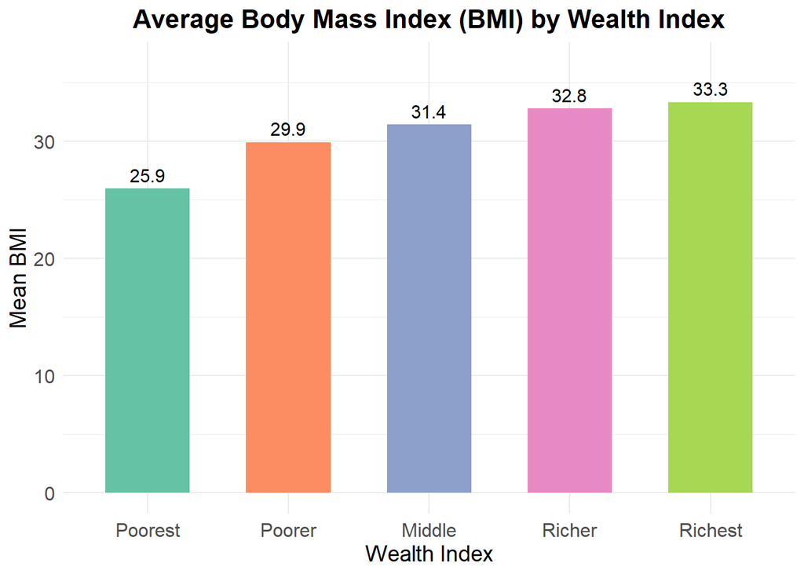

These imbalances have a direct impact on the nutritional health of children. Undernourished women are more likely to give birth to stunted or underweight children, while maternal obesity increases the risk of birth complications and metabolic disorders in children. This situation highlights the urgent need for targeted interventions to improve the nutritional status of women of childbearing age, with the aim of preventing child malnutrition.

| region | mean_bmi |
| --- | --- |
| libreville-port-gentil | 33.1 |
| estuaire | 31.94 |
| haut-ogooué | 28.83 |
| moyen-ogooué | 29.31 |
| ngounié | 25.04 |
| nyanga | 26.9 |
| ogooué maritime | 31.42 |
| ogooué-ivindo | 26.69 |
| ogooué-lolo | 28.58 |
| woleu-ntem | 31.56 |

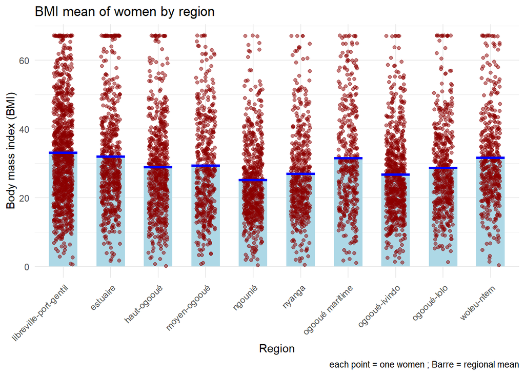

Regional BMI averages are all above 25, indicating that, on average, women are overweight in all provinces.

Example: in Libreville/Port-Gentil, the average BMI appears to be above 27. This study reveals significant nutritional disparities among women of reproductive age in Gabon. Socioeconomic factors such as wealth, education, and urban residence are closely linked to both undernutrition and overnutrition. The presence of severe obesity alongside underweight highlights the need for dual-focused interventions.

Given the impact of maternal nutrition on child health, these findings have major public health implications. Undernourished women are more likely to have underweight children, while obese mothers face risks such as gestational complications and childhood obesity.

Policy interventions should prioritize:

Nutrition education for all women, especially the uneducated and rural populations.

Promotion of balanced diets and physical activity.

Monitoring of urban dietary trends.

Reducing maternal malnutrition is essential for breaking the intergenerational cycle of poverty and poor health in Gabon. Even in less urbanized regions (Ngounié, Nyanga), the average BMI exceeds the optimum (18.5-24.9).

Presence of high extreme values (BMI > 50) in all regions, especially in urban provinces (Estuaire, Ogooué-Maritime), revealing cases of morbid obesity.

Significant intra-regional heterogeneity: even within the same province, BMIs vary widely, from underweight (BMI < 18.5) to severe obesity.

# 5 Conclusion

This study reveals significant nutritional disparities among women of reproductive age in Gabon. Socioeconomic factors such as wealth, education, and urban residence are closely linked to both undernutrition and overnutrition. The presence of severe obesity alongside underweight highlights the need for **dual-focused interventions**.

Given the impact of maternal nutrition on child health, these findings have major public health implications. Undernourished women are more likely to have underweight children, while obese mothers face risks such as gestational complications and childhood obesity.

**Policy interventions** should prioritize:

- **Nutrition education for all women, especially the uneducated and rural populations.**
- **Promotion of balanced diets and physical activity.**
- **Monitoring of urban dietary trends.**

Reducing maternal malnutrition is essential for breaking the intergenerational cycle of poverty and poor health in Gabon.